# Bellabeat : Smart Health Devices

Himanshu Dwivedi

2022-08-06

### Background

Bellabeat, a high-tech manufacturer of health-focused products for women is successful small company, but they have the potential to become a larger player in the global smart device market. Urška Sršen, cofounder and Chief Creative Officer of Bellabeat, believes that analyzing smart device fitness data could help unlock new growth opportunities for the company.

### Purpose of Data Analysis

This report will focus on one of Bellabeat’s products and analyze smart device data to gain insight into how consumers are using their smart devices. We would be looking deeper into the raw data and gather insights which will help in creating marketing strategy for the company.

### Stakeholders and intended audience

Important stakeholders involved in overall analysis are: * Bellabeat’s cofounder and Chief Creative Officer  
* Bellabeat executive team  
* A team of data analysts  
* Bellabeat’s Users

### Exploratory Data Analysis(EDA)

#### Tools for Analysis

Considering the size of the data and visualization needed to complete this analysis, R Programming is used.

```r
#Load the necessary libraries that will be utilized for the project
library(tidyverse)
library(lubridate)
library(janitor)
```

```r
library(dplyr)
library(ggplot2)
library(readr)
```

#### Loading Data

```r
#Loading csv files

Activity <- read_csv("C:/Users/Himan/OneDrive/Desktop/Project_Bellabeat/Fitabase Data 4.12.16-5.12.16/dailyActivity_merged.csv")
Calories <- read_csv("C:/Users/Himan/OneDrive/Desktop/Project_Bellabeat/Fitabase Data 4.12.16-5.12.16/dailyCalories_merged.csv")
Intensities <- read_csv("C:/Users/Himan/OneDrive/Desktop/Project_Bellabeat/Fitabase Data 4.12.16-5.12.16/dailyIntensities_merged.csv")
Steps <- read_csv("C:/Users/Himan/OneDrive/Desktop/Project_Bellabeat/Fitabase Data 4.12.16-5.12.16/dailySteps_merged.csv")
Sleep <- read_csv("C:/Users/Himan/OneDrive/Desktop/Project_Bellabeat/Fitabase Data 4.12.16-5.12.16/sleepDay_merged.csv")
Weight <- read_csv("C:/Users/Himan/OneDrive/Desktop/Project_Bellabeat/Fitabase Data 4.12.16-5.12.16/weightLogInfo_merged.csv")
Heart_rate <- read_csv("C:/Users/Himan/OneDrive/Desktop/Project_Bellabeat/Fitabase Data 4.12.16-5.12.16/heartrate_seconds_merged.csv")
```

#### Exploring Data

```r
#Exploring our data. we will use str(),head(),colnames and glimpse() functions.

glimpse(Activity)
```

```
## Rows: 940
## Columns: 15
## $ Id                       <dbl> 1503960366, 1503960366, 1503960366, 150396036…
## $ ActivityDate             <chr> "4/12/2016", "4/13/2016", "4/14/2016", "4/15/…
## $ TotalSteps               <dbl> 13162, 10735, 10460, 9762, 12669, 9705, 13019…
## $ TotalDistance            <dbl> 8.50, 6.97, 6.74, 6.28, 8.16, 6.48, 8.59, 9.8…
## $ TrackerDistance          <dbl> 8.50, 6.97, 6.74, 6.28, 8.16, 6.48, 8.59, 9.8…
## $ LoggedActivitiesDistance <dbl> 0, 0, 0, 0, 0, 0, 0, 0, 0, 0, 0, 0, 0, 0, 0, …
## $ VeryActiveDistance       <dbl> 1.88, 1.57, 2.44, 2.14, 2.71, 3.19, 3.25, 3.5…
## $ ModeratelyActiveDistance <dbl> 0.55, 0.69, 0.40, 1.26, 0.41, 0.78, 0.64, 1.3…
## $ LightActiveDistance      <dbl> 6.06, 4.71, 3.91, 2.83, 5.04, 2.51, 4.71, 5.0…
## $ SedentaryActiveDistance  <dbl> 0, 0, 0, 0, 0, 0, 0, 0, 0, 0, 0, 0, 0, 0, 0, …
## $ VeryActiveMinutes        <dbl> 25, 21, 30, 29, 36, 38, 42, 50, 28, 19, 66, 4…
## $ FairlyActiveMinutes      <dbl> 13, 19, 11, 34, 10, 20, 16, 31, 12, 8, 27, 21…
## $ LightlyActiveMinutes     <dbl> 328, 217, 181, 209, 221, 164, 233, 264, 205, …
## $ SedentaryMinutes         <dbl> 728, 776, 1218, 726, 773, 539, 1149, 775, 818…
## $ Calories                 <dbl> 1985, 1797, 1776, 1745, 1863, 1728, 1921, 203…
```

```r
glimpse(Calories)
```

```
## Rows: 940
## Columns: 3
## $ Id          <dbl> 1503960366, 1503960366, 1503960366, 1503960366, 1503960366…
## $ ActivityDay <chr> "4/12/2016", "4/13/2016", "4/14/2016", "4/15/2016", "4/16/…
## $ Calories    <dbl> 1985, 1797, 1776, 1745, 1863, 1728, 1921, 2035, 1786, 1775…
```

```r
glimpse(Intensities)
```

```
## Rows: 940
## Columns: 10
## $ Id                       <dbl> 1503960366, 1503960366, 1503960366, 150396036…
## $ ActivityDay              <chr> "4/12/2016", "4/13/2016", "4/14/2016", "4/15/…
## $ SedentaryMinutes         <dbl> 728, 776, 1218, 726, 773, 539, 1149, 775, 818…
## $ LightlyActiveMinutes     <dbl> 328, 217, 181, 209, 221, 164, 233, 264, 205, …
## $ FairlyActiveMinutes      <dbl> 13, 19, 11, 34, 10, 20, 16, 31, 12, 8, 27, 21…
## $ VeryActiveMinutes        <dbl> 25, 21, 30, 29, 36, 38, 42, 50, 28, 19, 66, 4…
## $ SedentaryActiveDistance  <dbl> 0, 0, 0, 0, 0, 0, 0, 0, 0, 0, 0, 0, 0, 0, 0, …
## $ LightActiveDistance      <dbl> 6.06, 4.71, 3.91, 2.83, 5.04, 2.51, 4.71, 5.0…
## $ ModeratelyActiveDistance <dbl> 0.55, 0.69, 0.40, 1.26, 0.41, 0.78, 0.64, 1.3…
## $ VeryActiveDistance       <dbl> 1.88, 1.57, 2.44, 2.14, 2.71, 3.19, 3.25, 3.5…
```

```r
glimpse(Sleep)
```

```
## Rows: 413
## Columns: 5
## $ Id                 <dbl> 1503960366, 1503960366, 1503960366, 1503960366, 150…
## $ SleepDay           <chr> "4/12/2016 12:00:00 AM", "4/13/2016 12:00:00 AM", "…
## $ TotalSleepRecords  <dbl> 1, 2, 1, 2, 1, 1, 1, 1, 1, 1, 1, 1, 1, 1, 1, 1, 1, …
## $ TotalMinutesAsleep <dbl> 327, 384, 412, 340, 700, 304, 360, 325, 361, 430, 2…
## $ TotalTimeInBed     <dbl> 346, 407, 442, 367, 712, 320, 377, 364, 384, 449, 3…
```

```r
glimpse(Steps)
```

```
## Rows: 940
## Columns: 3
## $ Id          <dbl> 1503960366, 1503960366, 1503960366, 1503960366, 1503960366…
## $ ActivityDay <chr> "4/12/2016", "4/13/2016", "4/14/2016", "4/15/2016", "4/16/…
## $ StepTotal   <dbl> 13162, 10735, 10460, 9762, 12669, 9705, 13019, 15506, 1054…
```

```r
glimpse(Weight)
```

```
## Rows: 67
## Columns: 8
## $ Id             <dbl> 1503960366, 1503960366, 1927972279, 2873212765, 2873212…
## $ Date           <chr> "5/2/2016 11:59:59 PM", "5/3/2016 11:59:59 PM", "4/13/2…
## $ WeightKg       <dbl> 52.6, 52.6, 133.5, 56.7, 57.3, 72.4, 72.3, 69.7, 70.3, …
## $ WeightPounds   <dbl> 115.9631, 115.9631, 294.3171, 125.0021, 126.3249, 159.6…
## $ Fat            <dbl> 22, NA, NA, NA, NA, 25, NA, NA, NA, NA, NA, NA, NA, NA,…
## $ BMI            <dbl> 22.65, 22.65, 47.54, 21.45, 21.69, 27.45, 27.38, 27.25,…
## $ IsManualReport <lgl> TRUE, TRUE, FALSE, TRUE, TRUE, TRUE, TRUE, TRUE, TRUE, …
## $ LogId          <dbl> 1.462234e+12, 1.462320e+12, 1.460510e+12, 1.461283e+12,…
```

```r
glimpse(Heart_rate)
```

```
## Rows: 2,483,658
## Columns: 3
## $ Id    <dbl> 2022484408, 2022484408, 2022484408, 2022484408, 2022484408, 2022…
## $ Time  <chr> "4/12/2016 7:21:00 AM", "4/12/2016 7:21:05 AM", "4/12/2016 7:21:…
## $ Value <dbl> 97, 102, 105, 103, 101, 95, 91, 93, 94, 93, 92, 89, 83, 61, 60, …
```

Observations- We can see that in every dataset Date is in character format so we will change it. Also at someplaces it written as activityday and some as activity date.

#### Cleaning and Formatting Data

```r
#Renaming & Converting date(char) into date(date) in Activity dataset
Activity <- Activity %>%
 rename(Date = ActivityDate) %>%
 mutate(Date = as.Date(Date,format="%m /%d /%y"))

#Renaming & Converting date(char) into date(date) in Calories dataset
Calories <- Calories %>%
 rename(Date = ActivityDay) %>%
 mutate(Date = as.Date(Date,format="%m /%d /%y"))

#Renaming & converting date(char) into date(date) in Intensities dataset
Intensities <- Intensities %>%
 rename(Date = ActivityDay) %>%
 mutate(Date = as.Date(Date,format="%m /%d /%y"))

#Renaming & converting date(char) into date(date) in Sleep dataset
Sleep <- Sleep %>%
rename(Date = SleepDay) %>%
mutate(Date = as.Date(Date,format="%m /%d /%y"))

#Renaming & converting date(char) into date(date) in Steps dataset
Steps <- Steps %>%
rename(Date = ActivityDay) %>%
mutate(Date = as.Date(Date,format="%m /%d /%y"))

#Converting date(char) into date(date) in Weight dataset
Weight <- Weight %>%
mutate(Date = as.Date(Date,format="%m /%d /%y"))
```

#### Distinct id feature in every dataset

```r
#checking distinct id feature in every dataset
n_distinct(Weight$Id)
```

```
## [1] 8
```

```r
n_distinct(Activity$Id)
```

```
## [1] 33
```

```r
n_distinct(Steps$Id)
```

```
## [1] 33
```

```r
n_distinct(Intensities$Id)
```

```
## [1] 33
```

```r
n_distinct(Calories$Id)
```

```
## [1] 33
```

```r
n_distinct(Sleep$Id)
```

```
## [1] 24
```

OBSERVATION- 33 Distinct values of ID in Activity, Steps, Intensities,Calories . Whereas only 8 people entered there weight and 24 tracked there sleep.

#### Null Values & Duplicates

```r
#checking duplicates and null values in Activity
sum(duplicated(Activity))
```

```
## [1] 0
```

```r
sum(is.na(Activity))
```

```
## [1] 0
```

```r
#checking duplicates and null values Calories
sum(duplicated(Calories))
```

```
## [1] 0
```

```r
sum(is.na(Calories))
```

```
## [1] 0
```

```r
#checking duplicates and null values Intensities
sum(duplicated(Intensities))
```

```
## [1] 0
```

```r
sum(is.na(Intensities))
```

```
## [1] 0
```

```r
#checking duplicates and null values Sleep
sum(duplicated(Sleep))
```

```
## [1] 3
```

```r
sum(is.na(Sleep))
```

```
## [1] 0
```

```r
#checking duplicates and null values Step
sum(duplicated(Steps))
```

```
## [1] 0
```

```r
sum(is.na(Steps))
```

```
## [1] 0
```

#### Removing the duplicates found in Sleep dataset

```r
#remove 3 duplicates we found
Sleep <- Sleep %>%
  distinct()
sum(duplicated(Sleep))
```

```
## [1] 0
```

#### Summary Statistics

```r
#statistics of TotalDistance and TotalSteps
Activity%>%
select(TotalDistance,
TotalSteps)%>%
summary()
```

```
##  TotalDistance      TotalSteps
##  Min.   : 0.000   Min.   :    0
##  1st Qu.: 2.620   1st Qu.: 3790
##  Median : 5.245   Median : 7406
##  Mean   : 5.490   Mean   : 7638
##  3rd Qu.: 7.713   3rd Qu.:10727
##  Max.   :28.030   Max.   :36019
```

```r
#statistics of TotalDistance , SedementaryMinutes and Calories
Activity%>%
select(TotalDistance,SedentaryMinutes,Calories)%>%
summary()
```

```
##  TotalDistance    SedentaryMinutes    Calories
##  Min.   : 0.000   Min.   :   0.0   Min.   :   0
##  1st Qu.: 2.620   1st Qu.: 729.8   1st Qu.:1828
##  Median : 5.245   Median :1057.5   Median :2134
##  Mean   : 5.490   Mean   : 991.2   Mean   :2304
##  3rd Qu.: 7.713   3rd Qu.:1229.5   3rd Qu.:2793
##  Max.   :28.030   Max.   :1440.0   Max.   :4900
```

```r
#statistics of Weight and BMI
Weight%>%
select(WeightKg,BMI)%>%
summary()
```

```
##     WeightKg           BMI
##  Min.   : 52.60   Min.   :21.45
##  1st Qu.: 61.40   1st Qu.:23.96
##  Median : 62.50   Median :24.39
##  Mean   : 72.04   Mean   :25.19
##  3rd Qu.: 85.05   3rd Qu.:25.56
##  Max.   :133.50   Max.   :47.54
```

OBSERVATION - From above statistics we can see a trend between steps, sedentaryminutes and Weight.(as steps increase the calories burnt increases.) We will create plots to confirm our hypothesis and see any other trends.

### Visualising Data

#### Creation of Plots

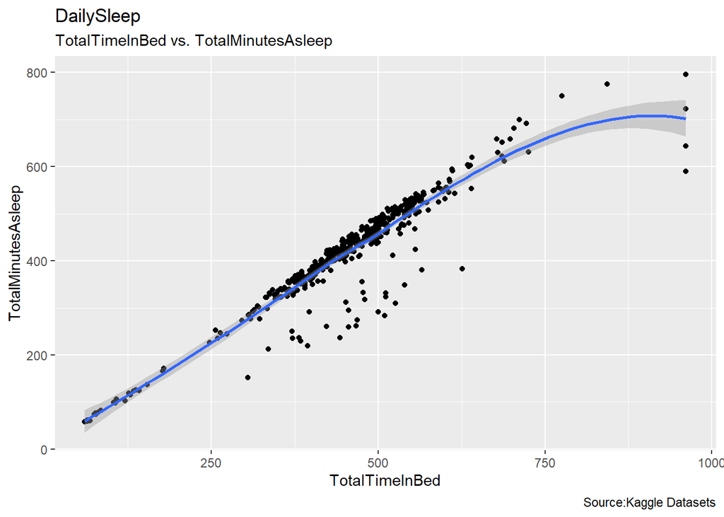

```r
#Creating Scatter Plot between TotalTimeInBed & TotalMinutesAsleep
ggplot(data=Sleep , aes(x=TotalTimeInBed, y=TotalMinutesAsleep)) +
  geom_point() +
  geom_smooth() +
  labs(title="DailySleep", subtitle ="TotalTimeInBed vs. TotalMinutesAsleep",caption ="Source:Kaggle Datasets")
```

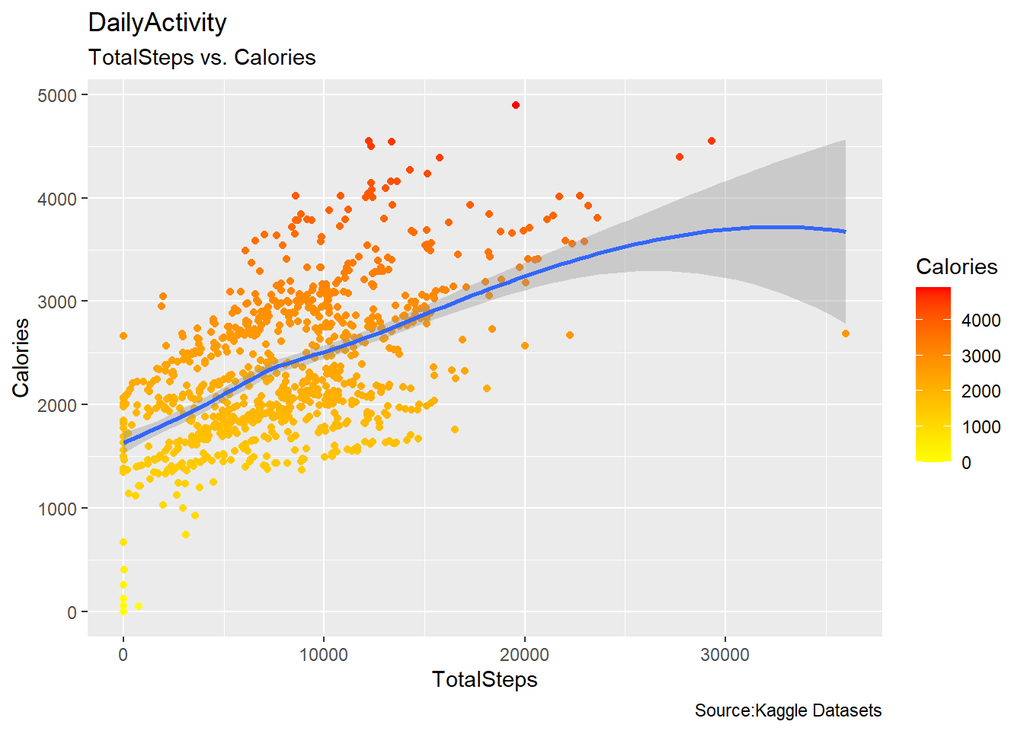

```r
#Creating Scatter Plot between TotalSteps & Calories
ggplot(data=Activity, mapping =aes(x=TotalSteps, y=Calories, color=Calories)) +
  geom_point() +
  geom_smooth(method ="loess" ) +
  labs(title="DailyActivity", subtitle ="TotalSteps vs. Calories", caption ="Source:Kaggle Datasets") +
  scale_color_gradient(low = "yellow", high ="red")
```

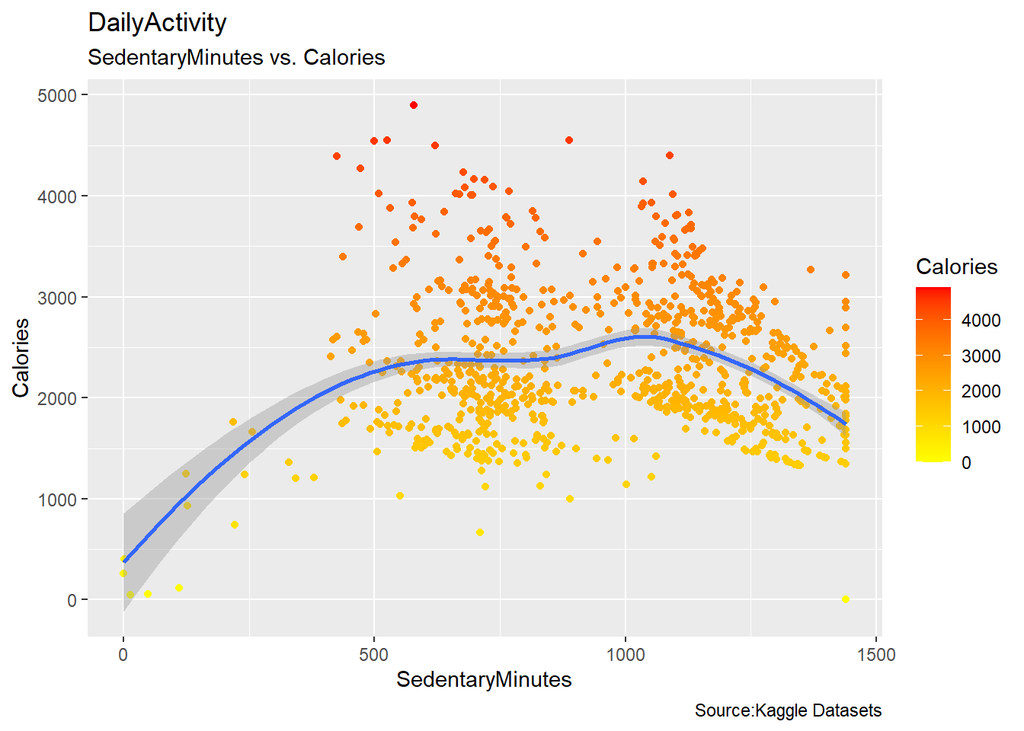

```r
#Creating Scatter Plot between SedentaryMinutes & Calories
ggplot(data=Activity, mapping =aes(x=SedentaryMinutes, y=Calories, color=Calories)) +
  geom_point() +
  geom_smooth(method ="loess" ) +
  labs(title="DailyActivity", subtitle ="SedentaryMinutes vs. Calories", caption ="Source:Kaggle Datasets") +
  scale_color_gradient(low = "yellow", high ="red")
```

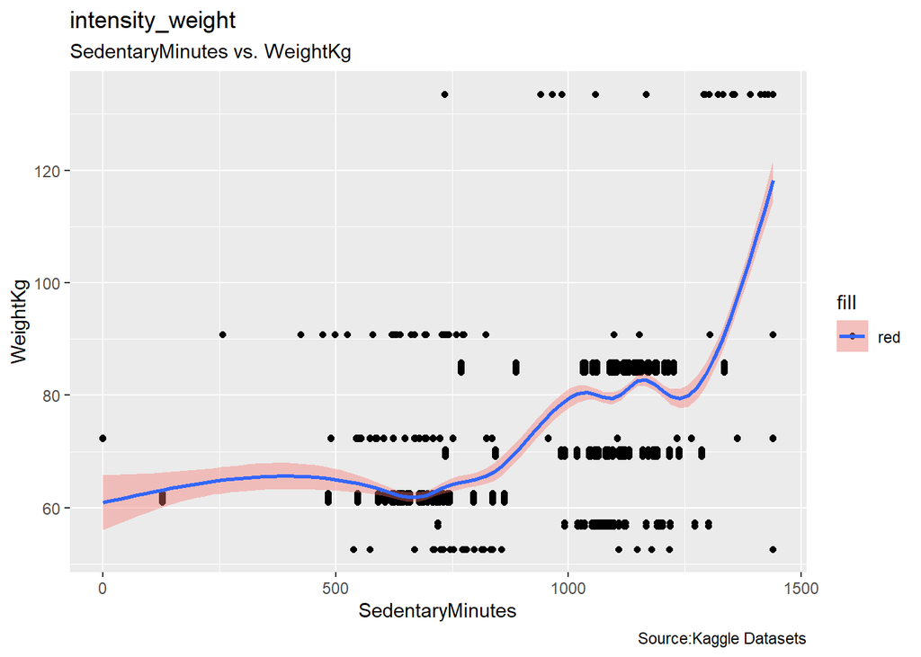

```r
#Creating Scatter Plot between SedentaryMinutes & Weight
intensity_weight<-merge(Intensities,Weight,by=c('Id'))
ggplot(data=intensity_weight, aes(x=SedentaryMinutes, y=WeightKg, fill="red")) + geom_point() + geom_smooth() + labs(title ="intensity_weight" , subtitle="SedentaryMinutes vs. WeightKg", caption = "Source:Kaggle Datasets")
```

### Recommendations

This report recommends the following: *Sample size was small so we sholud work on collecting more data.  
*People should be encouraged to log there weights.  
*company should send notifications on daily or weekly basis to keep customers informed about their activity.  
*Early warning signs can be added to their devices that can track any sudden changes in heart rate and other body signs.  
*The app interface should be simple so that customer can make entries easily.